# lnR_metabolomics: univariate analysis

Ming Yang

Compiled: October 12, 2021

# Data description and visualization

Data dimension: 170 metabolites X 60 samples

**60 samples in total**

- 5 genotypes: wt, wt/353, 74/211, 211/19, 19/74
- 2 ages: 15d, 30d
- 3 batches: 1, 2, 3

2 replicates per genotype per age per batch

**The 5 genotypes can be grouped by insulin resistance**

- insulin sensitive: wt, wt/353
- insulin resistant: 19/74, 74/211, 211/19

**The 5 genotypes can be grouped by fecundity**

- normal fecundity: wt, 74/211, 211/19
- high fecundity: wt/353
- low fecundity: 19/74

**The 5 genotypes can be grouped by tradeoff between longevity and fecundity**

- wt: wildtype
- mode.1: 19/74, 74/211, 211/19 are ‘mode.1’ transheterozygous genotypes using three mutation alleles (E19, 74, 211). These have longevity but reduced growth and reproduction along with low pAkt/insulin resistance. These genotypes may extend lifespan by reducing costs of reproduction.
- mode.2 : wt/353 is the ‘mode.2’ genotype (longevity but normal growth, reproduction, pAkt/insulin sensitivity). This genotype may provide ‘longevity assurance’

Plot two metabolite’s abundance among different modes and ages as examples

**note: metabolite abundance values were log-transformed and then sample-wise normalized (center and scale). No batch effect correction for this section’s plots.**

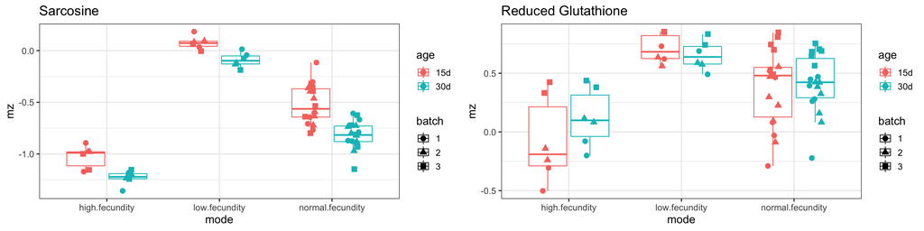

```r
mz.out.file='fecundity_candidate.mz.txt'

dat=readRDS('./mz.filter.dat.rds')
df.mat=dat$edata;
pheno=dat$pheno

## log transform
#summary(as.numeric(unlist(df.mat))) #no zero, log directly
df.mat.log=log(df.mat)

## normalize by sample
df.scaled=scale(df.mat.log,center=T,scale=T)
#apply(df.scaled,2,mean) #confirm
#apply(df.scaled,2,sd) #confirm

## mode setting
if(F){
# trade-off
#wt is wildtype
#wt/353 is the ‘Mode 2’, no trade-off
#the other three are the 'Mode 1', extend lifespan by reducing costs of reproduction.
pheno$mode='mode.1';
pheno[pheno$genotype=='wt/353',]$mode='mode.2'
pheno[pheno$genotype=='wt',]$mode='wt'
#table(pheno$mode)
#mode.1 mode.2     wt
#36     12     12
}
if(F){
#insulin sensitive: wt, wt/353
#insulin resistant: 19/74, 74/211, 211/19
pheno$mode=rep('insulin.resistant',nrow(pheno))
pheno[pheno$genotype %in% c('wt','wt/353'),]$mode='insulin.sensitive'
}

if(T){
#'normal' fecundity: wt, 74/211, 211/19
#high fecundity: wt/353
#low fecundity: 19/74
pheno$mode=rep('normal.fecundity',nrow(pheno))
pheno[pheno$genotype=='wt/353',]$mode='high.fecundity'
pheno[pheno$genotype=='19/74',]$mode='low.fecundity'
}
if(F){
#genotype
pheno$mode=pheno$genotype
}

#group.levels=c('wt 15d', 'wt 30d','mode.1 15d','mode.1 30d' ,'mode.2 15d', 'mode.2 30d')
group.levels=sort(unique(paste(pheno$mode,pheno$age)))
mode.levels=sort(unique(pheno$mode))

# select two metabolites
pick.mz=c('Sarcosine','Reduced Glutathione');
df.tmp=df.scaled[pick.mz,]
plots=lapply(1:nrow(df.tmp),function(i){
    mz=df.tmp[i,]
    mz.name=rownames(df.tmp)[i]
    tmp=data.frame(mz=as.numeric(mz),age=factor(pheno$age),mode=factor(pheno$mode),batch=factor(pheno$batch));
    tmp$group=factor(paste(tmp$mode,tmp$age))
    tmp$group=factor(tmp$group,levels=group.levels)
    tmp$mode=factor(tmp$mode,levels=mode.levels)

    ggplot(tmp,aes(x=mode,y=mz,col=age,group=group,shape=batch))+
      geom_boxplot(outlier.shape = NA) +
      geom_jitter(size=3,position = position_jitterdodge())+
      theme_bw(base_size = 14)+ggtitle(mz.name)
  })
  do.call(grid.arrange,c(plots,ncol=2))
```

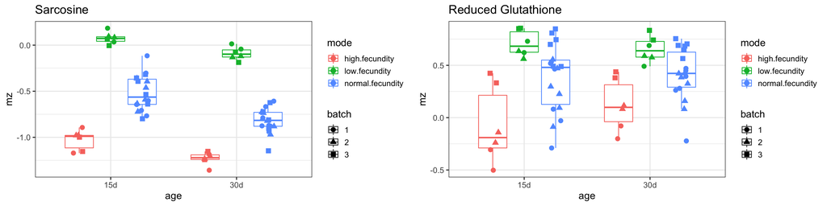

```r
  plots=lapply(1:nrow(df.tmp),function(i){
    mz=df.tmp[i,]
    mz.name=rownames(df.tmp)[i]
    tmp=data.frame(mz=as.numeric(mz),age=factor(pheno$age),mode=factor(pheno$mode),batch=factor(pheno$batch));
    tmp$group=factor(paste(tmp$mode,tmp$age))
    tmp$group=factor(tmp$group,levels=group.levels)
    tmp$mode=factor(tmp$mode,levels=mode.levels)
   ggplot(tmp,aes(x=age,y=mz,col=mode,group=group,shape=batch))+
    geom_boxplot(outlier.shape = NA) +
    geom_jitter(size=3,position = position_jitterdodge())+
    theme_bw(base_size = 14)+ggtitle(mz.name)
  })
  do.call(grid.arrange,c(plots,ncol=2))
```

In the following analysis, I performed linear regression analysis on each metabolite to identify those metabolites with a significant `age` or `mode` or `age:mode interaction` effect.

# linear regression on each metabolite with batch effect removed using `combat` function from `sva` R package

- **The data used in linear modelling have already been corrected for batch effect.**
- I performed linear regression on each metabolite using: **metabolite.abundance ~ age + mode + age:mode + error**
- I extracted the variance explained by the fitted linear model for each metabolite.
- I used `Anova` to test the significance of each term, i.e., age, mode, age:mode interaction term.
- The significance, or the P value, of each term for each metabolite was adjusted using `p.adjust` function in R with the `BH` method, referred to as `p.adj`.

```r
df.res=readRDS('mz.filter.combat.rds')
### use genotype and age as predictor
out=lapply(1:nrow(df.res),function(i){
  mz=df.res[i,]
  mz.name=rownames(df.res)[i] # fit model using df.res with age and mode as predictor, including interaction term
  tmp=data.frame(mz=as.numeric(mz),age=factor(pheno$age),mode=factor(pheno$mode));
  x=lm(mz~age*mode,tmp )
  x
})

# use Anova to get p values for each factor of each mz
#Anova(out[[1]])
sig.out=lapply(out,function(x){ #make a table
  x1=Anova(x)
  #x1=summary(x) #this gives you coef, coef.p.value for each term
  pvalue=x1$`Pr(>F)`
  #terms=rownames(x1)
  pvalue
})

df.sig.out=Reduce(`rbind`,sig.out)
x1=Anova(out[[1]])
colnames(df.sig.out)=rownames(x1)
rownames(df.sig.out)=rownames(df.res)
df.sig.out=df.sig.out[,-4] #remove Residuals column
#df.sig.out.adj=data.frame(matrix(p.adjust(df.sig.out,method = 'BH'),ncol=ncol(df.sig.out)))
df.sig.out.adj=data.frame(apply(df.sig.out,2,function(i) p.adjust(i,method='BH')))
#df.sig.out.adj=data.frame(apply(df.sig.out,2,function(i) p.adjust(i,method='fdr')))
rownames(df.sig.out.adj)=rownames(df.sig.out)
colnames(df.sig.out.adj)=colnames(df.sig.out)
```

After regression, for each metabolite, the variance explained by the fitted linear model is extracted through `adj.r.squared`.

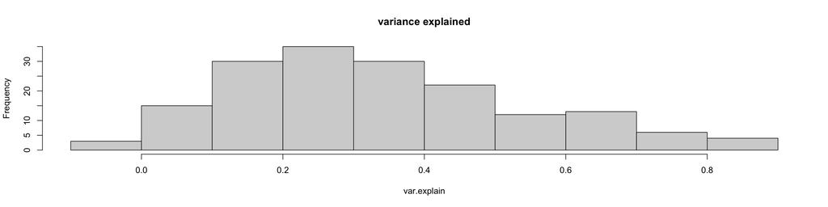

```r
var.explain=sapply(out,function(i) {x=summary(i);x$adj.r.squared})
hist(var.explain,main='variance explained')
```

There are 23 metabolites whose fitted linear model could explain at least 60% variance.

After regression, for each metabolite, there are 3 p.adj values, one for a predictor term:

```r
df.sig.out.adj[c(rownames(df.sig.out.adj)[1:3],pick.mz),]
```

|  | age | mode | age:mode |
| --- | --- | --- | --- |
| Ethanolamine | 7.169759e-01 | 1.078440e-06 | 0.59603722 |
| Glycine | 1.857626e-06 | 9.127121e-06 | 0.49647706 |
| betaAlanine | 2.222943e-04 | 1.184306e-04 | 0.09548159 |
| Sarcosine | 4.267669e-08 | 6.581236e-24 | 0.59603722 |
| Reduced Glutathione | 4.164301e-01 | 2.235239e-11 | 0.58653413 |

Have a look at the P.adj distributions for these three temrs:

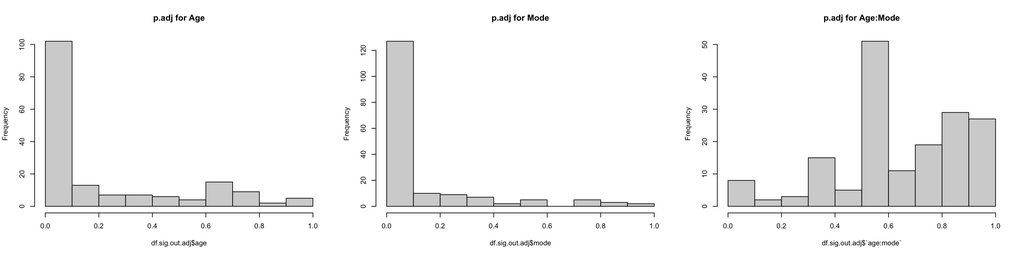

```r
par(mfrow=c(1,3))
hist(df.sig.out.adj$age,main='p.adj for Age')
hist(df.sig.out.adj$mode,main='p.adj for Mode')
hist(df.sig.out.adj$`age:mode`,main='p.adj for Age:Mode')
```

```r
p.value.cutoff=0.01;
```

After linear model fitting, the number of metabolites that were significantly affected by term(s) at a p.adj<0.01 cutoff:

```r
#nrow(df.sig.out.adj) #170
#df.sig.out.adj2=df.sig.out.adj[var.explain>=0.6,]
df.sig.out.adj2=df.sig.out.adj;
apply(df.sig.out.adj2,2,function(i){sum(i<p.value.cutoff)})
```

```
##      age     mode age:mode
##       63      102        4
```

```r
#rownames(df.sig.out.adj[df.sig.out.adj$mode<p.value.cutoff,])
#df.sig.out.adj['Sarcosine',]
```

# Visulization of metabolites that are affected by age, mode or their interactions (batch-corrected abundance values)

## metabolites affected by `age` alone

```r
#Select some metablites to visualize the model fitting (plot predictions)
#visreg: Visualization of regression functions
library(visreg)
#visreg(out[[1]],'genotype',by='age',overlay=T)

# some metabolites with only age effect
x1=df.sig.out.adj2$age;x2=df.sig.out.adj2$mode;x3=df.sig.out.adj2$`age:mod`;
i=which(x1<p.value.cutoff & x2>p.value.cutoff & x3>p.value.cutoff)
cat(length(i),'metabolites were only affected age\n')
```

```
## 32 metabolites were only affected age
```

Select one metabolite and plot its original abundance values (batch effect corrected):

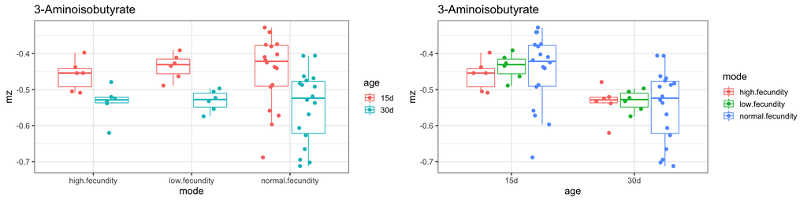

```r
pick=i[1]
mz.name=rownames(df.sig.out.adj2[pick,])

mz=df.res[pick,]
tmp=data.frame(mz=as.numeric(mz),age=factor(pheno$age),mode=factor(pheno$mode),batch=factor(pheno$batch));
tmp$group=factor(paste(tmp$mode,tmp$age))
tmp$group=factor(tmp$group,levels=group.levels)
tmp$mode=factor(tmp$mode,levels=mode.levels)

p1=ggplot(tmp,aes(x=mode,y=mz,col=age,group=group))+
    geom_boxplot(outlier.shape = NA) +
    geom_jitter(size=2,position = position_jitterdodge())+
    theme_bw(base_size = 14)+ggtitle(mz.name)
p2=ggplot(tmp,aes(x=age,y=mz,col=mode,group=group))+
    geom_boxplot(outlier.shape = NA) +
    geom_jitter(size=2,position = position_jitterdodge())+
    theme_bw(base_size = 14)+ggtitle(mz.name)
do.call(grid.arrange,c(list(p1,p2),ncol=2))
```

Plot model predicted values:

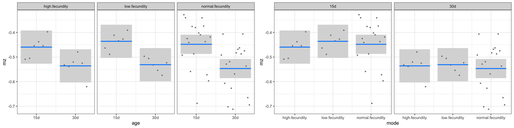

```r
# Model predictions as a function of age, for the three modes
p1=visreg(out[[pick]],'age',by='mode',overlay=F,main=paste0(mz.name,'\n\n'),gg=T)+theme_bw()
p2=visreg(out[[pick]],'mode',by='age',overlay=F,main=paste0(mz.name,'\n\n'),gg=T)+theme_bw()
do.call(grid.arrange,c(list(p1,p2),ncol=2))
```

## metabolites affected by `mode` alone

```r
# some metabolites with only mode effect
i=which(x1>p.value.cutoff & x2<p.value.cutoff & x3>p.value.cutoff)
cat(length(i),'metabolites were only affected mode\n')
```

```
## 73 metabolites were only affected mode
```

Select one metabolite. Plot original metabolite abundance values (batch effect corrected) and model predicted values:

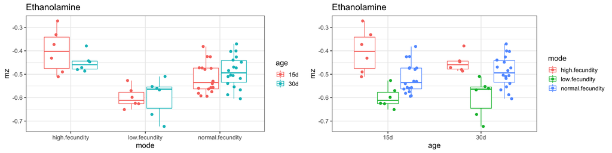

```r
pick=i[1]
mz.name=rownames(df.sig.out.adj2[pick,])

mz=df.res[pick,]
tmp=data.frame(mz=as.numeric(mz),age=factor(pheno$age),mode=factor(pheno$mode),batch=factor(pheno$batch));
tmp$group=factor(paste(tmp$mode,tmp$age))
tmp$group=factor(tmp$group,levels=group.levels)
tmp$mode=factor(tmp$mode,levels=mode.levels)

p1=ggplot(tmp,aes(x=mode,y=mz,col=age,group=group))+
    geom_boxplot(outlier.shape = NA) +
    geom_jitter(size=2,position = position_jitterdodge())+
    theme_bw(base_size = 14)+ggtitle(mz.name)
p2=ggplot(tmp,aes(x=age,y=mz,col=mode,group=group))+
    geom_boxplot(outlier.shape = NA) +
    geom_jitter(size=2,position = position_jitterdodge())+
    theme_bw(base_size = 14)+ggtitle(mz.name)
do.call(grid.arrange,c(list(p1,p2),ncol=2))
```

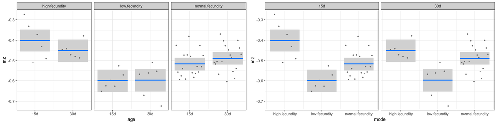

```r
p1=visreg(out[[pick]],'age',by='mode',overlay=F,main=paste0(mz.name,'\n\n'),gg=T)+theme_bw()
p2=visreg(out[[pick]],'mode',by='age',overlay=F,main=paste0(mz.name,'\n\n'),gg=T)+theme_bw()
do.call(grid.arrange,c(list(p1,p2),ncol=2))
```

## metabolites affected by both `age` and `mode`, but no interaction

```r
# some metabolites with both age and mode effect, no interaction
i=which(x1<p.value.cutoff & x2<p.value.cutoff & x3>p.value.cutoff)

cat(length(i),'metabolites were affected by both age and mode, but no interaction\n')
```

```
## 27 metabolites were affected by both age and mode, but no interaction
```

Select one metabolite. Plot original metabolite abundance values (batch effect corrected) and model predicted values:

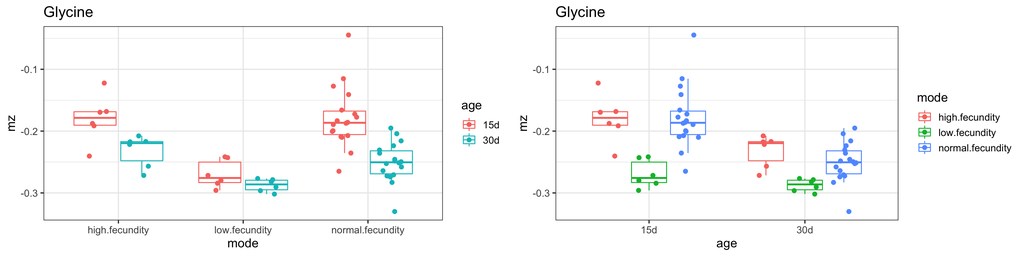

```r
pick=i[1]
mz.name=rownames(df.sig.out.adj2[pick,])

mz=df.res[pick,]
tmp=data.frame(mz=as.numeric(mz),age=factor(pheno$age),mode=factor(pheno$mode),batch=factor(pheno$batch));
tmp$group=factor(paste(tmp$mode,tmp$age))
tmp$group=factor(tmp$group,levels=group.levels)
tmp$mode=factor(tmp$mode,levels=mode.levels)

p1=ggplot(tmp,aes(x=mode,y=mz,col=age,group=group))+
    geom_boxplot(outlier.shape = NA) +
    geom_jitter(size=2,position = position_jitterdodge())+
    theme_bw(base_size = 14)+ggtitle(mz.name)
p2=ggplot(tmp,aes(x=age,y=mz,col=mode,group=group))+
    geom_boxplot(outlier.shape = NA) +
    geom_jitter(size=2,position = position_jitterdodge())+
    theme_bw(base_size = 14)+ggtitle(mz.name)
do.call(grid.arrange,c(list(p1,p2),ncol=2))
```

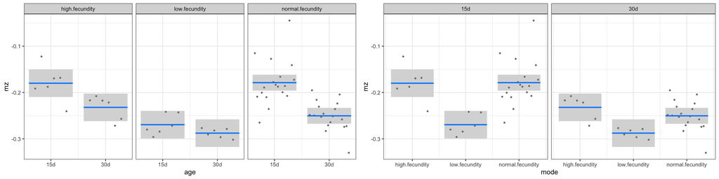

```r
p1=visreg(out[[pick]],'age',by='mode',overlay=F,main=paste0(mz.name,'\n\n'),gg=T)+theme_bw()
p2=visreg(out[[pick]],'mode',by='age',overlay=F,main=paste0(mz.name,'\n\n'),gg=T)+theme_bw()
do.call(grid.arrange,c(list(p1,p2),ncol=2))
```

## metabolites affected by both `age` and `mode`, and their interaction

```r
# some metabolites with both age and mode effect, yes interaction
i=which(x1<p.value.cutoff & x2<p.value.cutoff & x3<p.value.cutoff)
cat(length(i),'metabolites were affected by both age and mode, and their interaction\n')
```

```
## 2 metabolites were affected by both age and mode, and their interaction
```

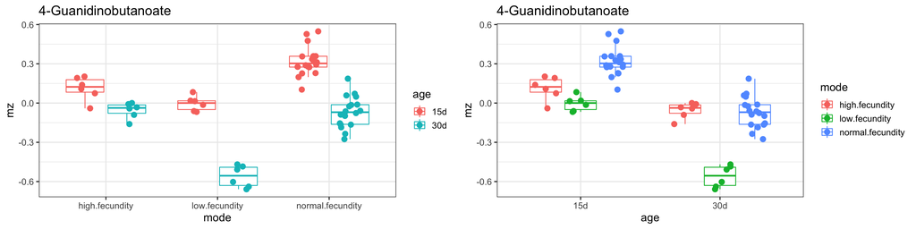

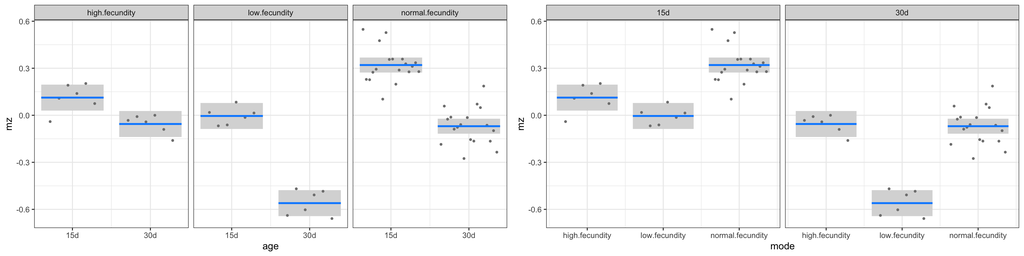

```r
if(!length(i)==0){
pick=i[1]
mz.name=rownames(df.sig.out.adj2[pick,])

mz=df.res[pick,]
tmp=data.frame(mz=as.numeric(mz),age=factor(pheno$age),mode=factor(pheno$mode),batch=factor(pheno$batch));
tmp$group=factor(paste(tmp$mode,tmp$age))
tmp$group=factor(tmp$group,levels=group.levels)
tmp$mode=factor(tmp$mode,levels=mode.levels)


p1=ggplot(tmp,aes(x=mode,y=mz,col=age,group=group))+
    geom_boxplot(outlier.shape = NA) +
    geom_jitter(size=3,position = position_jitterdodge())+
    theme_bw(base_size = 14)+ggtitle(mz.name)
p2=ggplot(tmp,aes(x=age,y=mz,col=mode,group=group))+
    geom_boxplot(outlier.shape = NA) +
    geom_jitter(size=3,position = position_jitterdodge())+
    theme_bw(base_size = 14)+ggtitle(mz.name)
do.call(grid.arrange,c(list(p1,p2),ncol=2))

p1=visreg(out[[pick]],'age',by='mode',overlay=F,main=paste0(mz.name,'\n\n'),gg=T)+theme_bw()
p2=visreg(out[[pick]],'mode',by='age',overlay=F,main=paste0(mz.name,'\n\n'),gg=T)+theme_bw()
do.call(grid.arrange,c(list(p1,p2),ncol=2))
}
```

# Tabular form of metabolites whose variance were explained by at least 60% of the fitted model and who were associated with mode at a p.adjust cutoff 0.01

```r
p.value.cutoff=0.01
df.sig.out.adj2=df.sig.out.adj[var.explain>=0.6 & df.sig.out.adj$mode<p.value.cutoff,]
df.sig.out.adj2$metabolite=rownames(df.sig.out.adj2)
data.table::fwrite(df.sig.out.adj2,mz.out.file)
#data.table::fwrite(df.sig.out.adj2,'fecundity_candidate.mz.txt')
df.sig.out.adj2
```

|  | age | mode | age:mode | metabolite |
| --- | --- | --- | --- | --- |
| Sarcosine | 4.267669e-08 | 6.581236e-24 | 0.5960372224 | Sarcosine |
| Histamine | 1.321305e-06 | 1.396715e-11 | 0.9949715543 | Histamine |
| Taurine | 1.340871e-05 | 1.817583e-10 | 0.5653031339 | Taurine |
| 4-Guanidinobutanoate | 2.442305e-18 | 1.844854e-14 | 0.0037737632 | 4-Guanidinobutanoate |
| Deoxycarnitine | 1.233844e-11 | 2.338341e-06 | 0.5381739048 | Deoxycarnitine |
| Methionine | 1.122558e-08 | 1.385593e-09 | 0.5986657302 | Methionine |
| Dimethylarginine (A/SDMA) | 1.739198e-05 | 8.722488e-10 | 0.4964770603 | Dimethylarginine (A/SDMA) |
| L-Kynurenine | 1.981469e-05 | 2.211671e-09 | 0.0249330974 | L-Kynurenine |
| Thiamine | 2.995282e-04 | 1.136879e-13 | 0.6718132907 | Thiamine |
| FAD | 6.599723e-08 | 5.051939e-10 | 0.2998609833 | FAD |

[output cut: 11 more lines]